# pm566_a2

Author

Stella Zhou

# Data Wrangling

```r
chs_ind <- read.csv("chs_individual.csv")
chs_reg <- read.csv("chs_regional.csv")
chs_merge <- merge(x=chs_ind, y=chs_reg, all=TRUE)

sum(is.na(chs_merge$townname))
```

```
[1] 0
```

## 1. check demension

```r
dim(chs_ind)
```

```
[1] 1200   23
```

```r
dim(chs_reg)
```

```
[1] 12 27
```

```r
dim(chs_merge)
```

```
[1] 1200   49
```

recode missing values

```r
library(data.table)
library(dplyr)
library(dtplyr)
library(tidyverse)
library(lubridate)
chs_merge <- data.table(chs_merge)
```

```r
chs_MH <-
  chs_merge %>%
  filter (male == 1 & hispanic == 1)
```

Replace missing values with mean of continuous variables

```r
chs_merge[is.na(agepft), agepft := mean(chs_MH$agepft, na.rm = TRUE)]
chs_merge[is.na(height), height := mean(chs_MH$height, na.rm = TRUE)]
chs_merge[is.na(weight), weight := mean(chs_MH$weight, na.rm = TRUE)]
chs_merge[is.na(bmi), bmi := mean(chs_MH$bmi, na.rm = TRUE)]
chs_merge[is.na(fev), fev := mean(chs_MH$fev, na.rm = TRUE)]
chs_merge[is.na(fvc), fvc := mean(chs_MH$fvc, na.rm = TRUE)]
chs_merge[is.na(mmef), mmef := mean(chs_MH$mmef, na.rm = TRUE)]
chs_merge[is.na(educ_parent), educ_parent := mean(chs_MH$educ_parent, na.rm = TRUE)]
```

```r
sum(is.na(chs_merge$smoke_gas_exposure))
```

```
[1] 0
```

```r
chs_merge[is.na(asthma), asthma := round(mean(chs_MH$asthma, na.rm = TRUE), 1)]
chs_merge[is.na(smoke), smoke := round(mean(chs_MH$smoke, na.rm = TRUE), 1)]
chs_merge[is.na(gasstove), gasstove := round(mean(chs_MH$gasstove, na.rm = TRUE), 1)]
```

## 2. Create a new categorical variable “obesity_level” from BMI

```r
chs_merge <- as.data.frame(chs_merge)
chs_merge <-
  chs_merge %>%
  mutate(obesity_level = case_when(chs_merge$bmi < 14  ~ 'Underweight',
                              chs_merge$bmi >= 14 & chs_merge$bmi < 22  ~ 'Normal',
                              chs_merge$bmi >= 22 & chs_merge$bmi < 24  ~ 'Overweight',
                              chs_merge$bmi >= 24  ~ 'Obese'))
```

```r
chs_merge %>%
  group_by(obesity_level) %>%
  summarise(min_bmi = min(bmi),
            max_bmi = max(bmi),
            n_bmi = n())
```

```
# A tibble: 4 × 4
  obesity_level min_bmi max_bmi n_bmi
  <chr>           <dbl>   <dbl> <int>
1 Normal           14.0    22.0   975
2 Obese            24.0    41.3   103
3 Overweight       22.0    24.0    87
4 Underweight      11.3    14.0    35
```

## 3. Create variable ’smoke_gas_exposure”

```r
chs_merge <-
  chs_merge %>%
  mutate(smoke_gas_exposure = case_when(
    chs_merge$smoke == 0 & chs_merge$gasstove == 0 ~ 'No exposure',
    chs_merge$smoke == 0 & chs_merge$gasstove == 1 ~ 'Gas exposure',
    chs_merge$smoke == 1 & chs_merge$gasstove == 0 ~ 'Smoke exposure',
    chs_merge$smoke == 1 & chs_merge$gasstove == 1 ~ 'Smoke & gas exposure'))
table(chs_merge$smoke_gas_exposure)
```

```
        Gas exposure          No exposure Smoke & gas exposure
                 761                  249                  151
      Smoke exposure
                  39
```

## 4. FEV by town, sex, obesity level, smoke gas exposure

By town

```r
chs_merge %>%
  group_by(townname) %>%
  summarise(n = n(),
            mean_fev  = mean(fev),
            sd_fev  = sd(fev))
```

```
# A tibble: 12 × 4
   townname          n mean_fev sd_fev
   <chr>         <int>    <dbl>  <dbl>
 1 Alpine          100    2091.   291.
 2 Atascadero      100    2081.   324.
 3 Lake Elsinore   100    2047.   304.
 4 Lake Gregory    100    2095.   319.
 5 Lancaster       100    2017.   318.
 6 Lompoc          100    2046.   351.
 7 Long Beach      100    1993.   321.
 8 Mira Loma       100    1994.   326.
 9 Riverside       100    1998.   279.
10 San Dimas       100    2030.   319.
11 Santa Maria     100    2033.   313.
12 Upland          100    2035.   343.
```

By sex

```r
chs_merge %>%
  group_by(male) %>%
  summarise(n = n(),
            mean_fev  = mean(fev),
            sd_fev  = sd(fev))
```

```
# A tibble: 2 × 4
   male     n mean_fev sd_fev
  <int> <int>    <dbl>  <dbl>
1     0   610    1974.   315.
2     1   590    2105.   308.
```

By obesity level

```r
chs_merge %>%
  group_by(obesity_level) %>%
  summarise(n = n(),
            mean_fev  = mean(fev),
            sd_fev  = sd(fev))
```

```
# A tibble: 4 × 4
  obesity_level     n mean_fev sd_fev
  <chr>         <int>    <dbl>  <dbl>
1 Normal          975    2010.   296.
2 Obese           103    2268.   324.
3 Overweight       87    2224.   317.
4 Underweight      35    1699.   305.
```

By smoke gas stove exposure

```r
chs_merge %>%
  group_by(smoke_gas_exposure) %>%
  summarise(n = n(),
            mean_fev  = mean(fev),
            sd_fev  = sd(fev))
```

```
# A tibble: 4 × 4
  smoke_gas_exposure       n mean_fev sd_fev
  <chr>                <int>    <dbl>  <dbl>
1 Gas exposure           761    2034.   318.
2 No exposure            249    2047.   333.
3 Smoke & gas exposure   151    2029.   300.
4 Smoke exposure          39    2093.   297.
```

# EDA checklist

```r
summary(chs_merge$bmi)
```

```
   Min. 1st Qu.  Median    Mean 3rd Qu.    Max.
  11.30   15.96   17.81   18.57   19.99   41.27
```

```r
summary(chs_merge$fev)
```

```
   Min. 1st Qu.  Median    Mean 3rd Qu.    Max.
  984.8  1827.6  2060.1  2038.3  2223.6  3323.7
```

```r
table(chs_merge$smoke_gas_exposure)
```

```
        Gas exposure          No exposure Smoke & gas exposure
                 761                  249                  151
      Smoke exposure
                  39
```

```r
summary(chs_merge$pm25_mass)
```

```
   Min. 1st Qu.  Median    Mean 3rd Qu.    Max.
  5.960   7.615  10.545  14.362  20.988  29.970
```

# Visualization

## 1. BMI vs. FEV by townname

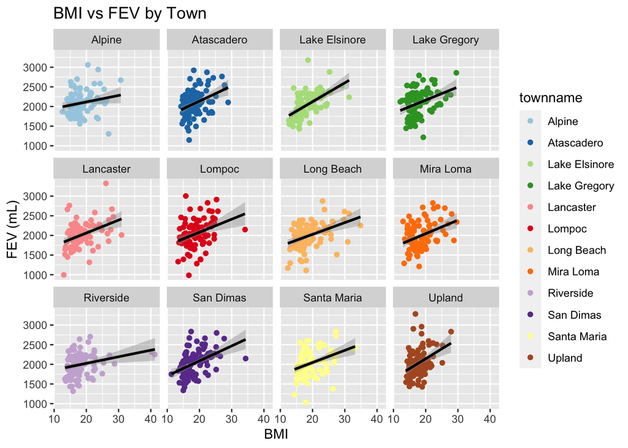

```r
library(ggplot2)

chs_merge %>%
  ggplot(aes(x = bmi, y = fev, group = townname)) +
  geom_point(mapping = aes(x = bmi, y = fev, color = townname)) +
  geom_smooth(method = "lm", color='black') +
  scale_color_brewer(palette = "Paired") +
  facet_wrap( ~ townname, nrow= 3) +
  ggtitle("BMI vs FEV by Town") +
  xlab("BMI") +
  ylab("FEV (mL)")
```

For each town in the CHS communities, there appears to be a positive linear association between FEV and BMI. Some towns have stronger association than others, however it is hugely impacted by outliers.

## 2. Stacked histograms of FEV by BMI category and FEV by smoke/gas exposure.

1. By BMI categroy

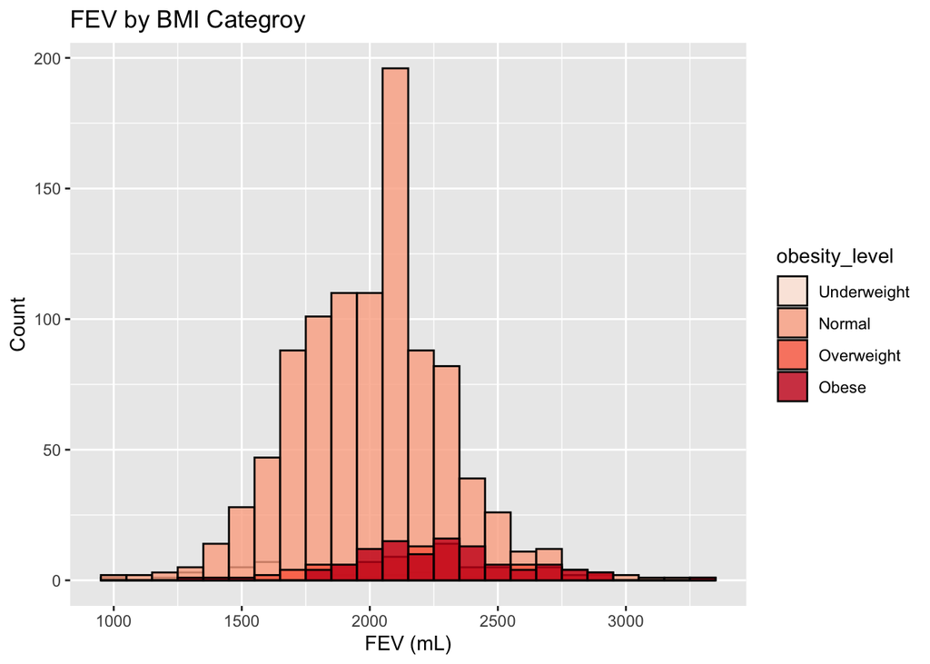

```r
chs_merge$obesity_level <- factor(chs_merge$obesity_level, levels = c("Underweight", "Normal", "Overweight", "Obese"))

chs_merge %>%
  ggplot(mapping = aes(x = fev, fill = obesity_level)) +
  geom_histogram(position = "identity", alpha = 0.8, binwidth = 100, color="black") +
  scale_fill_brewer(palette = "Reds") +
  ggtitle("FEV by BMI Categroy") +
  xlab("FEV (mL)") +
  ylab("Count")
```

From the stacked histogram, we can see that the distribution of FEV is slightly more left skewed in overweight and obese population than underweight and normal population.

2. By smoke gas exposure

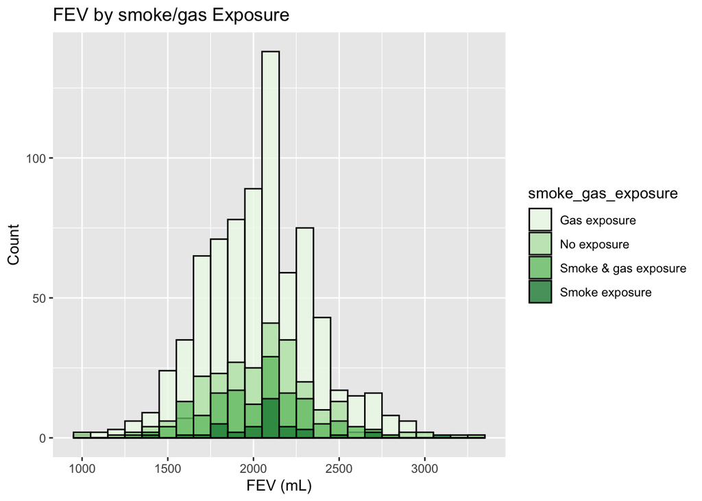

```r
chs_merge %>%
  ggplot(mapping = aes(x = fev, fill = smoke_gas_exposure)) +
  geom_histogram(position = "identity", alpha = 0.8, binwidth = 100, color="black") +
  scale_fill_brewer(palette = "Greens") +
  ggtitle("FEV by smoke/gas Exposure") +
  xlab("FEV (mL)") +
  ylab("Count")
```

Based on the stacked histogram of FEV by smoke/gas exposure, there is no obvious difference in distribution between the four groups, however there the gas stove exposure only group is the most abundant.

## 3. Bar chart of BMI by smoke/gas exposure

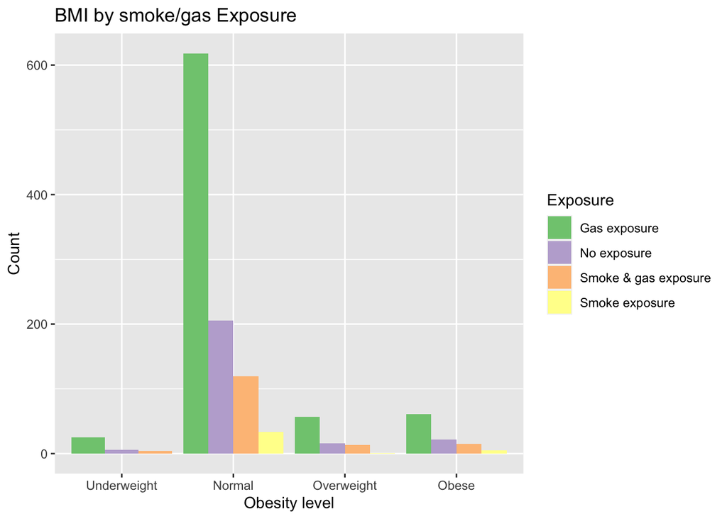

```r
chs_merge %>%
  ggplot(mapping = aes(x = obesity_level, fill = smoke_gas_exposure)) +
  geom_bar(position = "dodge") +
  scale_fill_brewer(palette = "Accent") +
  ggtitle("BMI by smoke/gas Exposure") +
  xlab("Obesity level") +
  ylab("Count") +
  labs(fill="Exposure")
```

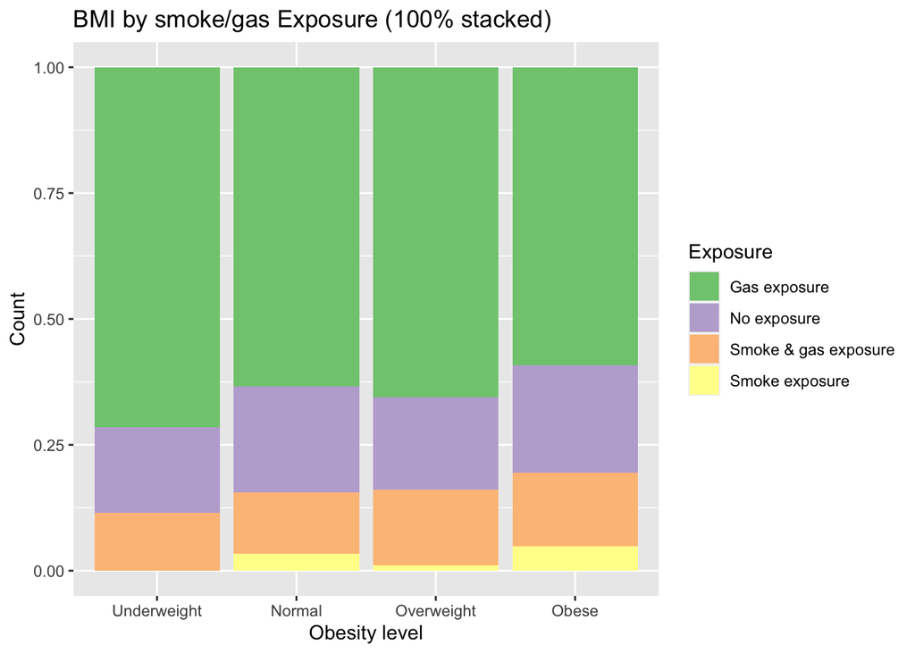

```r
chs_merge %>%
  ggplot(mapping = aes(x = obesity_level, fill = smoke_gas_exposure)) +
  geom_bar(position = "fill") +
  scale_fill_brewer(palette = "Accent") +
  ggtitle("BMI by smoke/gas Exposure (100% stacked)") +
  xlab("Obesity level") +
  ylab("Count") +
  labs(fill="Exposure")
```

The bar chart of BMI by smoke and gas expsure shows that gas stove only takes up the largest proportion in all BMI categories, followed by no exposure, smoke and gas exposure, and smoke exposure only. From the 100% stacked bar chart we can see that the frequency of each type of exposure is approximately the same across all BMI categories. Interestingly, compared to normal and underweight population, a larger proportion in the overweight and obese population is exposed to smoke.

## 4. Statistical summary graphs of FEV by BMI and FEV by smoke/gas exposure category.

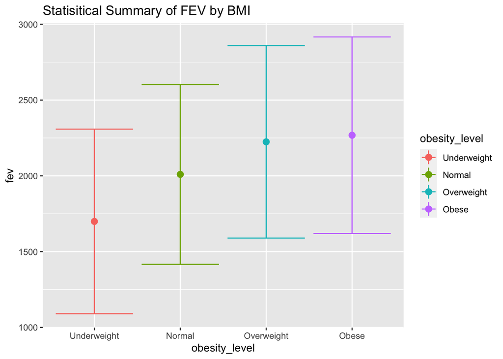

```r
chs_merge %>%
    ggplot(mapping = aes(x = obesity_level, y = fev, color = obesity_level)) +
    stat_summary(fun.data = mean_sdl, geom = "pointrange") +
    stat_summary(fun.data = mean_sdl, geom = "errorbar")+
  labs (title = "Statisitical Summary of FEV by BMI")
```

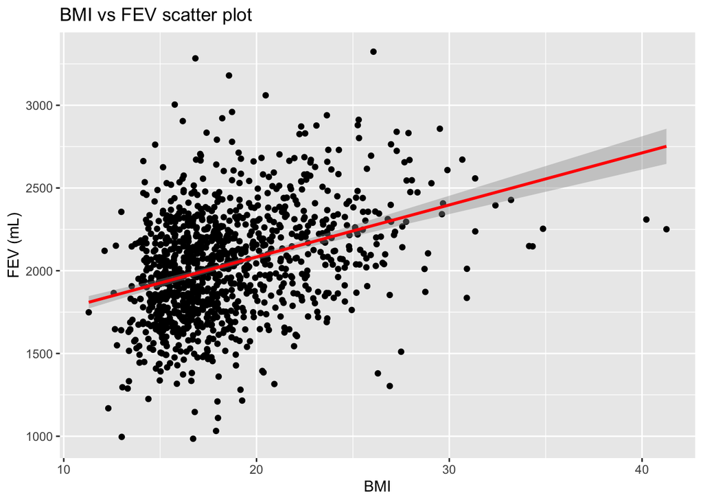

```r
chs_merge %>%
  ggplot(aes(x = bmi, y = fev)) +
  geom_point(mapping = aes(x = bmi, y = fev)) +
  geom_smooth(method = "lm", color='red') +
  ggtitle("BMI vs FEV scatter plot") +
  xlab("BMI") +
  ylab("FEV (mL)")
```

## 5. A leaflet map showing the concentrations of PM2.5 mass in each of the CHS communities.

```r
library(leaflet)

temp.pal <- colorFactor(c('lightgreen','darkred'), domain = chs_merge$pm25_mass)

leaflet(chs_merge) %>%
  addProviderTiles('CartoDB.Positron') %>%
  addCircles(
    lat = ~lat, lng = ~lon, color = ~temp.pal(pm25_mass),
    opacity = 1, fillOpacity = 1, radius = 100) %>%
  addLegend('bottomleft', pal=temp.pal, chs_merge$pm25_mass,
            title='PM2.5', opacity=1)
```

[interactive chart not shown]

The highest PM2.5 mass is located in San Bernardino and the lowest PM2.5 mass up North in Santa Barbara and Santa Maria.